# Risk Factor Analysis

## Outcome Variable

**Outcome Variable:** wast_rec90d

## Predictor Variables

**Intervention Variable:** meducyrs

**Adjustment Set:**

- arm
- W_mage
- feducyrs
- hhwealth_quart
- W_mhtcm
- W_mwtkg
- W_mbmi
- W_gagebrth
- W_birthwt
- W_birthlen
- single
- W_nrooms
- impsan
- delta_W_mage
- delta_feducyrs
- delta_hhwealth_quart
- delta_W_mhtcm
- delta_W_mwtkg
- delta_W_mbmi
- delta_W_gagebrth
- delta_W_birthwt
- delta_W_birthlen
- delta_single
- delta_W_nrooms
- delta_impsan

## Stratifying Variables

The analysis was stratified on these variable(s):

- agecat
- studyid
- country

## Data Summary

| agecat | studyid | country | meducyrs | wast_rec90d | n_cell | n |
| --- | --- | --- | --- | --- | --- | --- |
| 0-24 months | CMC-V-BCS-2002 | INDIA | High | 0 | 40 | 324 |
| 0-24 months | CMC-V-BCS-2002 | INDIA | High | 1 | 82 | 324 |
| 0-24 months | CMC-V-BCS-2002 | INDIA | Low | 0 | 38 | 324 |
| 0-24 months | CMC-V-BCS-2002 | INDIA | Low | 1 | 62 | 324 |
| 0-24 months | CMC-V-BCS-2002 | INDIA | Medium | 0 | 42 | 324 |
| 0-24 months | CMC-V-BCS-2002 | INDIA | Medium | 1 | 60 | 324 |
| 0-24 months | COHORTS | GUATEMALA | High | 0 | 36 | 377 |
| 0-24 months | COHORTS | GUATEMALA | High | 1 | 30 | 377 |
| 0-24 months | COHORTS | GUATEMALA | Low | 0 | 105 | 377 |
| 0-24 months | COHORTS | GUATEMALA | Low | 1 | 76 | 377 |
| 0-24 months | COHORTS | GUATEMALA | Medium | 0 | 70 | 377 |
| 0-24 months | COHORTS | GUATEMALA | Medium | 1 | 60 | 377 |
| 0-24 months | COHORTS | INDIA | High | 0 | 144 | 2119 |
| 0-24 months | COHORTS | INDIA | High | 1 | 62 | 2119 |
| 0-24 months | COHORTS | INDIA | Low | 0 | 696 | 2119 |
| 0-24 months | COHORTS | INDIA | Low | 1 | 168 | 2119 |
| 0-24 months | COHORTS | INDIA | Medium | 0 | 771 | 2119 |
| 0-24 months | COHORTS | INDIA | Medium | 1 | 278 | 2119 |
| 0-24 months | COHORTS | PHILIPPINES | High | 0 | 202 | 1689 |
| 0-24 months | COHORTS | PHILIPPINES | High | 1 | 380 | 1689 |
| 0-24 months | COHORTS | PHILIPPINES | Low | 0 | 255 | 1689 |
| 0-24 months | COHORTS | PHILIPPINES | Low | 1 | 323 | 1689 |
| 0-24 months | COHORTS | PHILIPPINES | Medium | 0 | 207 | 1689 |
| 0-24 months | COHORTS | PHILIPPINES | Medium | 1 | 322 | 1689 |
| 0-24 months | EE | PAKISTAN | High | 0 | 2 | 320 |
| 0-24 months | EE | PAKISTAN | High | 1 | 7 | 320 |
| 0-24 months | EE | PAKISTAN | Low | 0 | 146 | 320 |
| 0-24 months | EE | PAKISTAN | Low | 1 | 144 | 320 |
| 0-24 months | EE | PAKISTAN | Medium | 0 | 10 | 320 |
| 0-24 months | EE | PAKISTAN | Medium | 1 | 11 | 320 |

[output cut: 438 more lines]

The following strata were considered:

- agecat: 0-24 months, studyid: CMC-V-BCS-2002, country: INDIA
- agecat: 0-24 months, studyid: COHORTS, country: GUATEMALA
- agecat: 0-24 months, studyid: COHORTS, country: INDIA
- agecat: 0-24 months, studyid: COHORTS, country: PHILIPPINES
- agecat: 0-24 months, studyid: EE, country: PAKISTAN
- agecat: 0-24 months, studyid: GMS-Nepal, country: NEPAL
- agecat: 0-24 months, studyid: Guatemala BSC, country: GUATEMALA
- agecat: 0-24 months, studyid: IRC, country: INDIA
- agecat: 0-24 months, studyid: JiVitA-3, country: BANGLADESH
- agecat: 0-24 months, studyid: JiVitA-4, country: BANGLADESH
- agecat: 0-24 months, studyid: LCNI-5, country: MALAWI
- agecat: 0-24 months, studyid: MAL-ED, country: BANGLADESH
- agecat: 0-24 months, studyid: MAL-ED, country: BRAZIL
- agecat: 0-24 months, studyid: MAL-ED, country: INDIA
- agecat: 0-24 months, studyid: MAL-ED, country: NEPAL
- agecat: 0-24 months, studyid: MAL-ED, country: PERU
- agecat: 0-24 months, studyid: MAL-ED, country: SOUTH AFRICA
- agecat: 0-24 months, studyid: MAL-ED, country: TANZANIA, UNITED REPUBLIC OF
- agecat: 0-24 months, studyid: NIH-Birth, country: BANGLADESH
- agecat: 0-24 months, studyid: NIH-Crypto, country: BANGLADESH
- agecat: 0-24 months, studyid: PROBIT, country: BELARUS
- agecat: 0-24 months, studyid: PROVIDE, country: BANGLADESH
- agecat: 0-24 months, studyid: SAS-CompFeed, country: INDIA
- agecat: 0-24 months, studyid: SAS-FoodSuppl, country: INDIA
- agecat: 0-24 months, studyid: TanzaniaChild2, country: TANZANIA, UNITED REPUBLIC OF
- agecat: 0-24 months, studyid: ZVITAMBO, country: ZIMBABWE
- agecat: 0-6 months, studyid: CMC-V-BCS-2002, country: INDIA
- agecat: 0-6 months, studyid: COHORTS, country: GUATEMALA
- agecat: 0-6 months, studyid: COHORTS, country: INDIA
- agecat: 0-6 months, studyid: COHORTS, country: PHILIPPINES
- agecat: 0-6 months, studyid: EE, country: PAKISTAN
- agecat: 0-6 months, studyid: GMS-Nepal, country: NEPAL
- agecat: 0-6 months, studyid: Guatemala BSC, country: GUATEMALA
- agecat: 0-6 months, studyid: IRC, country: INDIA
- agecat: 0-6 months, studyid: JiVitA-3, country: BANGLADESH
- agecat: 0-6 months, studyid: JiVitA-4, country: BANGLADESH
- agecat: 0-6 months, studyid: LCNI-5, country: MALAWI
- agecat: 0-6 months, studyid: MAL-ED, country: BANGLADESH
- agecat: 0-6 months, studyid: MAL-ED, country: BRAZIL
- agecat: 0-6 months, studyid: MAL-ED, country: INDIA
- agecat: 0-6 months, studyid: MAL-ED, country: NEPAL
- agecat: 0-6 months, studyid: MAL-ED, country: PERU
- agecat: 0-6 months, studyid: MAL-ED, country: SOUTH AFRICA
- agecat: 0-6 months, studyid: MAL-ED, country: TANZANIA, UNITED REPUBLIC OF
- agecat: 0-6 months, studyid: NIH-Birth, country: BANGLADESH
- agecat: 0-6 months, studyid: NIH-Crypto, country: BANGLADESH
- agecat: 0-6 months, studyid: PROBIT, country: BELARUS
- agecat: 0-6 months, studyid: PROVIDE, country: BANGLADESH
- agecat: 0-6 months, studyid: SAS-CompFeed, country: INDIA
- agecat: 0-6 months, studyid: SAS-FoodSuppl, country: INDIA
- agecat: 0-6 months, studyid: TanzaniaChild2, country: TANZANIA, UNITED REPUBLIC OF
- agecat: 0-6 months, studyid: ZVITAMBO, country: ZIMBABWE
- agecat: 6-24 months, studyid: CMC-V-BCS-2002, country: INDIA
- agecat: 6-24 months, studyid: COHORTS, country: GUATEMALA
- agecat: 6-24 months, studyid: COHORTS, country: INDIA
- agecat: 6-24 months, studyid: COHORTS, country: PHILIPPINES
- agecat: 6-24 months, studyid: EE, country: PAKISTAN
- agecat: 6-24 months, studyid: GMS-Nepal, country: NEPAL
- agecat: 6-24 months, studyid: Guatemala BSC, country: GUATEMALA
- agecat: 6-24 months, studyid: IRC, country: INDIA
- agecat: 6-24 months, studyid: JiVitA-3, country: BANGLADESH
- agecat: 6-24 months, studyid: JiVitA-4, country: BANGLADESH
- agecat: 6-24 months, studyid: LCNI-5, country: MALAWI
- agecat: 6-24 months, studyid: MAL-ED, country: BANGLADESH
- agecat: 6-24 months, studyid: MAL-ED, country: BRAZIL
- agecat: 6-24 months, studyid: MAL-ED, country: INDIA
- agecat: 6-24 months, studyid: MAL-ED, country: NEPAL
- agecat: 6-24 months, studyid: MAL-ED, country: PERU
- agecat: 6-24 months, studyid: MAL-ED, country: SOUTH AFRICA
- agecat: 6-24 months, studyid: MAL-ED, country: TANZANIA, UNITED REPUBLIC OF
- agecat: 6-24 months, studyid: NIH-Birth, country: BANGLADESH
- agecat: 6-24 months, studyid: NIH-Crypto, country: BANGLADESH
- agecat: 6-24 months, studyid: PROBIT, country: BELARUS
- agecat: 6-24 months, studyid: PROVIDE, country: BANGLADESH
- agecat: 6-24 months, studyid: SAS-CompFeed, country: INDIA
- agecat: 6-24 months, studyid: SAS-FoodSuppl, country: INDIA
- agecat: 6-24 months, studyid: TanzaniaChild2, country: TANZANIA, UNITED REPUBLIC OF
- agecat: 6-24 months, studyid: ZVITAMBO, country: ZIMBABWE

### Dropped Strata

Some strata were dropped due to rare outcomes:

- agecat: 0-24 months, studyid: EE, country: PAKISTAN
- agecat: 0-24 months, studyid: Guatemala BSC, country: GUATEMALA
- agecat: 0-24 months, studyid: LCNI-5, country: MALAWI
- agecat: 0-24 months, studyid: MAL-ED, country: BRAZIL
- agecat: 0-24 months, studyid: MAL-ED, country: NEPAL
- agecat: 0-24 months, studyid: MAL-ED, country: PERU
- agecat: 0-24 months, studyid: MAL-ED, country: SOUTH AFRICA
- agecat: 0-24 months, studyid: MAL-ED, country: TANZANIA, UNITED REPUBLIC OF
- agecat: 0-24 months, studyid: SAS-FoodSuppl, country: INDIA
- agecat: 0-6 months, studyid: EE, country: PAKISTAN
- agecat: 0-6 months, studyid: Guatemala BSC, country: GUATEMALA
- agecat: 0-6 months, studyid: LCNI-5, country: MALAWI
- agecat: 0-6 months, studyid: MAL-ED, country: BANGLADESH
- agecat: 0-6 months, studyid: MAL-ED, country: BRAZIL
- agecat: 0-6 months, studyid: MAL-ED, country: NEPAL
- agecat: 0-6 months, studyid: MAL-ED, country: PERU
- agecat: 0-6 months, studyid: MAL-ED, country: SOUTH AFRICA
- agecat: 0-6 months, studyid: MAL-ED, country: TANZANIA, UNITED REPUBLIC OF
- agecat: 0-6 months, studyid: SAS-FoodSuppl, country: INDIA
- agecat: 0-6 months, studyid: TanzaniaChild2, country: TANZANIA, UNITED REPUBLIC OF
- agecat: 6-24 months, studyid: COHORTS, country: GUATEMALA
- agecat: 6-24 months, studyid: COHORTS, country: INDIA
- agecat: 6-24 months, studyid: EE, country: PAKISTAN
- agecat: 6-24 months, studyid: Guatemala BSC, country: GUATEMALA
- agecat: 6-24 months, studyid: JiVitA-3, country: BANGLADESH
- agecat: 6-24 months, studyid: LCNI-5, country: MALAWI
- agecat: 6-24 months, studyid: MAL-ED, country: BANGLADESH
- agecat: 6-24 months, studyid: MAL-ED, country: BRAZIL
- agecat: 6-24 months, studyid: MAL-ED, country: NEPAL
- agecat: 6-24 months, studyid: MAL-ED, country: PERU
- agecat: 6-24 months, studyid: MAL-ED, country: SOUTH AFRICA
- agecat: 6-24 months, studyid: MAL-ED, country: TANZANIA, UNITED REPUBLIC OF
- agecat: 6-24 months, studyid: NIH-Crypto, country: BANGLADESH
- agecat: 6-24 months, studyid: PROBIT, country: BELARUS
- agecat: 6-24 months, studyid: SAS-FoodSuppl, country: INDIA

## Methods Detail

We’re interested in the causal parameters $E[Y_a]$ for all values of $a \in \mathcal{A}$. These parameters represent the mean outcome if, possibly contrary to fact, we intervened to set all units to have $A=a$. Under the randomization and positivity assumptions, these are identified by the statistical parameters $\psi_a=E_W[E_{Y|A,W}(Y|A=a,W)]$. In addition, we’re interested in the mean of $Y$, $E[Y]$ under no intervention (the observed mean). We will estimate these parameters by using SuperLearner to fit the relevant likelihood factors – $E_{Y|A,W}(Y|A=a,W)$ and $p(A=a|W)$, and then updating our likelihood fit using a joint TMLE.

For unadjusted analyses ($W=\{\}$), initial likelihoods were estimated using Lrnr_glm to estimate the simple $E(Y|A)$ and Lrnr_mean to estimate $p(A)$. For adjusted analyses, a small library containing Lrnr_glmnet, Lrnr_xgboost, and Lrnr_mean was used.

Having estimated these parameters, we will then use the delta method to estimate relative risks and attributable risks relative to a prespecified baseline level of $A$.

# Results Detail

## Results Plots

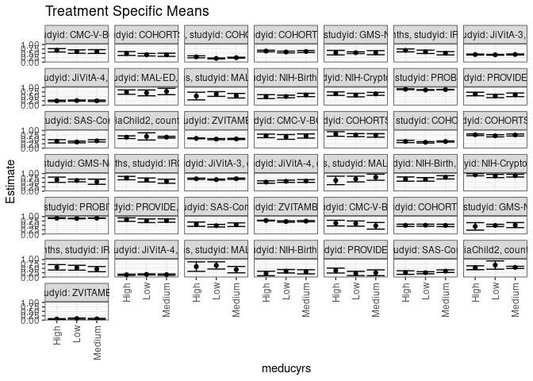

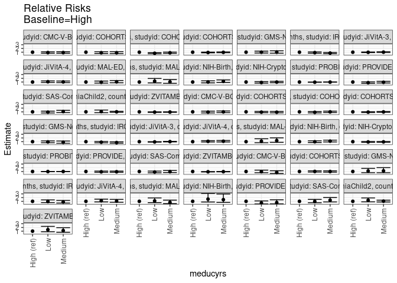

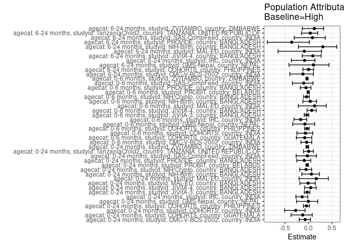

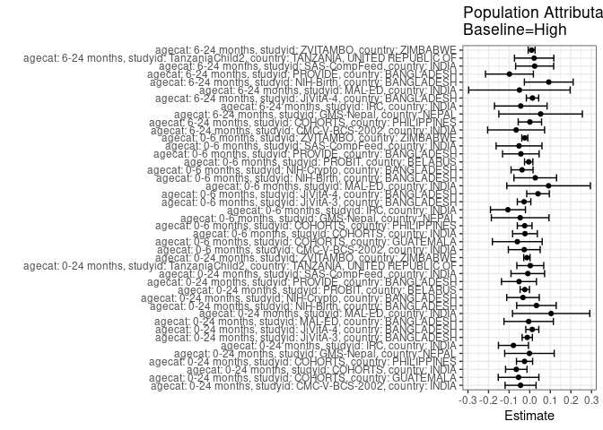

## Results Table

### Parameter: TSM

| agecat | studyid | country | intervention_level | baseline_level | estimate | ci_lower | ci_upper |
| --- | --- | --- | --- | --- | --- | --- | --- |
| 0-24 months | CMC-V-BCS-2002 | INDIA | High | NA | 0.6740124 | 0.5788514 | 0.7691734 |
| 0-24 months | CMC-V-BCS-2002 | INDIA | Low | NA | 0.6011559 | 0.5043983 | 0.6979135 |
| 0-24 months | CMC-V-BCS-2002 | INDIA | Medium | NA | 0.6035705 | 0.4968580 | 0.7102830 |
| 0-24 months | COHORTS | GUATEMALA | High | NA | 0.4946009 | 0.3833945 | 0.6058074 |
| 0-24 months | COHORTS | GUATEMALA | Low | NA | 0.4241003 | 0.3525013 | 0.4956993 |
| 0-24 months | COHORTS | GUATEMALA | Medium | NA | 0.4205880 | 0.3326878 | 0.5084882 |
| 0-24 months | COHORTS | INDIA | High | NA | 0.3048704 | 0.2488428 | 0.3608980 |
| 0-24 months | COHORTS | INDIA | Low | NA | 0.2160276 | 0.1900398 | 0.2420153 |
| 0-24 months | COHORTS | INDIA | Medium | NA | 0.2559961 | 0.2309392 | 0.2810530 |
| 0-24 months | COHORTS | PHILIPPINES | High | NA | 0.6320231 | 0.5866955 | 0.6773506 |
| 0-24 months | COHORTS | PHILIPPINES | Low | NA | 0.5790749 | 0.5320604 | 0.6260895 |
| 0-24 months | COHORTS | PHILIPPINES | Medium | NA | 0.6065159 | 0.5519994 | 0.6610324 |
| 0-24 months | GMS-Nepal | NEPAL | High | NA | 0.5403268 | 0.4135492 | 0.6671044 |
| 0-24 months | GMS-Nepal | NEPAL | Low | NA | 0.5386564 | 0.4897544 | 0.5875583 |
| 0-24 months | GMS-Nepal | NEPAL | Medium | NA | 0.5402921 | 0.4228237 | 0.6577604 |
| 0-24 months | IRC | INDIA | High | NA | 0.6689462 | 0.5863608 | 0.7515316 |
| 0-24 months | IRC | INDIA | Low | NA | 0.5878154 | 0.4921747 | 0.6834561 |
| 0-24 months | IRC | INDIA | Medium | NA | 0.5083135 | 0.4145875 | 0.6020394 |
| 0-24 months | JiVitA-3 | BANGLADESH | High | NA | 0.4343715 | 0.4073785 | 0.4613644 |
| 0-24 months | JiVitA-3 | BANGLADESH | Low | NA | 0.4209635 | 0.3966945 | 0.4452325 |
| 0-24 months | JiVitA-3 | BANGLADESH | Medium | NA | 0.4396880 | 0.4127469 | 0.4666291 |
| 0-24 months | JiVitA-4 | BANGLADESH | High | NA | 0.2454309 | 0.2085449 | 0.2823169 |
| 0-24 months | JiVitA-4 | BANGLADESH | Low | NA | 0.2635325 | 0.2310481 | 0.2960170 |
| 0-24 months | JiVitA-4 | BANGLADESH | Medium | NA | 0.2520464 | 0.2128348 | 0.2912579 |
| 0-24 months | MAL-ED | BANGLADESH | High | NA | 0.7407407 | 0.6159882 | 0.8654933 |
| 0-24 months | MAL-ED | BANGLADESH | Low | NA | 0.6969697 | 0.5338973 | 0.8600421 |
| 0-24 months | MAL-ED | BANGLADESH | Medium | NA | 0.7777778 | 0.5967442 | 0.9588114 |
| 0-24 months | MAL-ED | INDIA | High | NA | 0.5193689 | 0.3028030 | 0.7359347 |
| 0-24 months | MAL-ED | INDIA | Low | NA | 0.6356639 | 0.5015724 | 0.7697553 |
| 0-24 months | MAL-ED | INDIA | Medium | NA | 0.5379544 | 0.4088819 | 0.6670270 |

[output cut: 99 more lines]

### Parameter: E(Y)

| agecat | studyid | country | intervention_level | baseline_level | estimate | ci_lower | ci_upper |
| --- | --- | --- | --- | --- | --- | --- | --- |
| 0-24 months | CMC-V-BCS-2002 | INDIA | NA | NA | 0.6296296 | 0.5734927 | 0.6857666 |
| 0-24 months | COHORTS | GUATEMALA | NA | NA | 0.4403183 | 0.3884516 | 0.4921850 |
| 0-24 months | COHORTS | INDIA | NA | NA | 0.2397357 | 0.2214428 | 0.2580286 |
| 0-24 months | COHORTS | PHILIPPINES | NA | NA | 0.6068680 | 0.5823645 | 0.6313715 |
| 0-24 months | GMS-Nepal | NEPAL | NA | NA | 0.5390625 | 0.4966112 | 0.5815138 |
| 0-24 months | IRC | INDIA | NA | NA | 0.5898734 | 0.5376978 | 0.6420491 |
| 0-24 months | JiVitA-3 | BANGLADESH | NA | NA | 0.4224309 | 0.4113024 | 0.4335594 |
| 0-24 months | JiVitA-4 | BANGLADESH | NA | NA | 0.2580019 | 0.2386523 | 0.2773515 |
| 0-24 months | MAL-ED | BANGLADESH | NA | NA | 0.7356322 | 0.6433278 | 0.8279366 |
| 0-24 months | MAL-ED | INDIA | NA | NA | 0.6233766 | 0.5382453 | 0.7085080 |
| 0-24 months | NIH-Birth | BANGLADESH | NA | NA | 0.5201900 | 0.4695846 | 0.5707955 |
| 0-24 months | NIH-Crypto | BANGLADESH | NA | NA | 0.6225806 | 0.5684562 | 0.6767051 |
| 0-24 months | PROBIT | BELARUS | NA | NA | 0.8806715 | 0.8711794 | 0.8901636 |
| 0-24 months | PROVIDE | BANGLADESH | NA | NA | 0.5811688 | 0.5245443 | 0.6377934 |
| 0-24 months | SAS-CompFeed | INDIA | NA | NA | 0.3808354 | 0.3457640 | 0.4159068 |
| 0-24 months | TanzaniaChild2 | TANZANIA, UNITED REPUBLIC OF | NA | NA | 0.6264045 | 0.5887191 | 0.6640899 |
| 0-24 months | ZVITAMBO | ZIMBABWE | NA | NA | 0.5430867 | 0.5266769 | 0.5594965 |
| 0-6 months | CMC-V-BCS-2002 | INDIA | NA | NA | 0.6716418 | 0.6057305 | 0.7375531 |
| 0-6 months | COHORTS | GUATEMALA | NA | NA | 0.7452830 | 0.6866274 | 0.8039386 |
| 0-6 months | COHORTS | INDIA | NA | NA | 0.3595188 | 0.3344897 | 0.3845478 |
| 0-6 months | COHORTS | PHILIPPINES | NA | NA | 0.7367021 | 0.7051294 | 0.7682749 |
| 0-6 months | GMS-Nepal | NEPAL | NA | NA | 0.6030534 | 0.5432663 | 0.6628406 |
| 0-6 months | IRC | INDIA | NA | NA | 0.6375000 | 0.5751450 | 0.6998550 |
| 0-6 months | JiVitA-3 | BANGLADESH | NA | NA | 0.6754071 | 0.6620619 | 0.6887522 |
| 0-6 months | JiVitA-4 | BANGLADESH | NA | NA | 0.5583942 | 0.5167799 | 0.6000084 |
| 0-6 months | MAL-ED | INDIA | NA | NA | 0.7027027 | 0.5947731 | 0.8106323 |
| 0-6 months | NIH-Birth | BANGLADESH | NA | NA | 0.7130045 | 0.6535890 | 0.7724200 |
| 0-6 months | NIH-Crypto | BANGLADESH | NA | NA | 0.8934010 | 0.8497799 | 0.9370221 |
| 0-6 months | PROBIT | BELARUS | NA | NA | 0.9008671 | 0.8918443 | 0.9098900 |
| 0-6 months | PROVIDE | BANGLADESH | NA | NA | 0.7837838 | 0.7252863 | 0.8422812 |
| 0-6 months | SAS-CompFeed | INDIA | NA | NA | 0.5131965 | 0.4596632 | 0.5667297 |
| 0-6 months | ZVITAMBO | ZIMBABWE | NA | NA | 0.7474145 | 0.7304420 | 0.7643869 |
| 6-24 months | CMC-V-BCS-2002 | INDIA | NA | NA | 0.5609756 | 0.4682842 | 0.6536670 |
| 6-24 months | COHORTS | PHILIPPINES | NA | NA | 0.5026681 | 0.4688378 | 0.5364984 |
| 6-24 months | GMS-Nepal | NEPAL | NA | NA | 0.4947090 | 0.4399319 | 0.5494861 |
| 6-24 months | IRC | INDIA | NA | NA | 0.5161290 | 0.4322562 | 0.6000019 |
| 6-24 months | JiVitA-4 | BANGLADESH | NA | NA | 0.1492734 | 0.1316631 | 0.1668838 |
| 6-24 months | MAL-ED | INDIA | NA | NA | 0.5500000 | 0.4255057 | 0.6744943 |
| 6-24 months | NIH-Birth | BANGLADESH | NA | NA | 0.3030303 | 0.2377927 | 0.3682679 |
| 6-24 months | PROVIDE | BANGLADESH | NA | NA | 0.2764228 | 0.1950773 | 0.3577682 |
| 6-24 months | SAS-CompFeed | INDIA | NA | NA | 0.2854123 | 0.2436284 | 0.3271961 |
| 6-24 months | TanzaniaChild2 | TANZANIA, UNITED REPUBLIC OF | NA | NA | 0.5564516 | 0.5041613 | 0.6087419 |
| 6-24 months | ZVITAMBO | ZIMBABWE | NA | NA | 0.0739726 | 0.0585427 | 0.0894025 |

### Parameter: RR

| agecat | studyid | country | intervention_level | baseline_level | estimate | ci_lower | ci_upper |
| --- | --- | --- | --- | --- | --- | --- | --- |
| 0-24 months | CMC-V-BCS-2002 | INDIA | High | High | 1.0000000 | 1.0000000 | 1.0000000 |
| 0-24 months | CMC-V-BCS-2002 | INDIA | Low | High | 0.8919063 | 0.7190756 | 1.1062771 |
| 0-24 months | CMC-V-BCS-2002 | INDIA | Medium | High | 0.8954887 | 0.7140151 | 1.1230855 |
| 0-24 months | COHORTS | GUATEMALA | High | High | 1.0000000 | 1.0000000 | 1.0000000 |
| 0-24 months | COHORTS | GUATEMALA | Low | High | 0.8574596 | 0.6563832 | 1.1201337 |
| 0-24 months | COHORTS | GUATEMALA | Medium | High | 0.8503583 | 0.6334046 | 1.1416231 |
| 0-24 months | COHORTS | INDIA | High | High | 1.0000000 | 1.0000000 | 1.0000000 |
| 0-24 months | COHORTS | INDIA | Low | High | 0.7085882 | 0.5736001 | 0.8753436 |
| 0-24 months | COHORTS | INDIA | Medium | High | 0.8396882 | 0.6880004 | 1.0248194 |
| 0-24 months | COHORTS | PHILIPPINES | High | High | 1.0000000 | 1.0000000 | 1.0000000 |
| 0-24 months | COHORTS | PHILIPPINES | Low | High | 0.9162244 | 0.8223141 | 1.0208595 |
| 0-24 months | COHORTS | PHILIPPINES | Medium | High | 0.9596420 | 0.8556056 | 1.0763287 |
| 0-24 months | GMS-Nepal | NEPAL | High | High | 1.0000000 | 1.0000000 | 1.0000000 |
| 0-24 months | GMS-Nepal | NEPAL | Low | High | 0.9969084 | 0.7751459 | 1.2821152 |
| 0-24 months | GMS-Nepal | NEPAL | Medium | High | 0.9999356 | 0.7266554 | 1.3759911 |
| 0-24 months | IRC | INDIA | High | High | 1.0000000 | 1.0000000 | 1.0000000 |
| 0-24 months | IRC | INDIA | Low | High | 0.8787185 | 0.7165032 | 1.0776592 |
| 0-24 months | IRC | INDIA | Medium | High | 0.7598720 | 0.6089054 | 0.9482679 |
| 0-24 months | JiVitA-3 | BANGLADESH | High | High | 1.0000000 | 1.0000000 | 1.0000000 |
| 0-24 months | JiVitA-3 | BANGLADESH | Low | High | 0.9691326 | 0.8916199 | 1.0533838 |
| 0-24 months | JiVitA-3 | BANGLADESH | Medium | High | 1.0122396 | 0.9290079 | 1.1029283 |
| 0-24 months | JiVitA-4 | BANGLADESH | High | High | 1.0000000 | 1.0000000 | 1.0000000 |
| 0-24 months | JiVitA-4 | BANGLADESH | Low | High | 1.0737545 | 0.8889339 | 1.2970015 |
| 0-24 months | JiVitA-4 | BANGLADESH | Medium | High | 1.0269545 | 0.8314718 | 1.2683959 |
| 0-24 months | MAL-ED | BANGLADESH | High | High | 1.0000000 | 1.0000000 | 1.0000000 |
| 0-24 months | MAL-ED | BANGLADESH | Low | High | 0.9409091 | 0.7050517 | 1.2556667 |
| 0-24 months | MAL-ED | BANGLADESH | Medium | High | 1.0500000 | 0.7881118 | 1.3989132 |
| 0-24 months | MAL-ED | INDIA | High | High | 1.0000000 | 1.0000000 | 1.0000000 |
| 0-24 months | MAL-ED | INDIA | Low | High | 1.2239160 | 0.7647333 | 1.9588140 |
| 0-24 months | MAL-ED | INDIA | Medium | High | 1.0357849 | 0.6418920 | 1.6713877 |

[output cut: 99 more lines]

### Parameter: PAR

| agecat | studyid | country | intervention_level | baseline_level | estimate | ci_lower | ci_upper |
| --- | --- | --- | --- | --- | --- | --- | --- |
| 0-24 months | CMC-V-BCS-2002 | INDIA | High | NA | -0.0443828 | -0.1195739 | 0.0308084 |
| 0-24 months | COHORTS | GUATEMALA | High | NA | -0.0542826 | -0.1528784 | 0.0443131 |
| 0-24 months | COHORTS | INDIA | High | NA | -0.0651347 | -0.1172990 | -0.0129704 |
| 0-24 months | COHORTS | PHILIPPINES | High | NA | -0.0251551 | -0.0643043 | 0.0139941 |
| 0-24 months | GMS-Nepal | NEPAL | High | NA | -0.0012643 | -0.1215109 | 0.1189823 |
| 0-24 months | IRC | INDIA | High | NA | -0.0790728 | -0.1519534 | -0.0061921 |
| 0-24 months | JiVitA-3 | BANGLADESH | High | NA | -0.0119406 | -0.0367850 | 0.0129039 |
| 0-24 months | JiVitA-4 | BANGLADESH | High | NA | 0.0125710 | -0.0189530 | 0.0440950 |
| 0-24 months | MAL-ED | BANGLADESH | High | NA | -0.0051086 | -0.1250382 | 0.1148211 |
| 0-24 months | MAL-ED | INDIA | High | NA | 0.1040077 | -0.0835959 | 0.2916114 |
| 0-24 months | NIH-Birth | BANGLADESH | High | NA | 0.0327081 | -0.0631699 | 0.1285861 |
| 0-24 months | NIH-Crypto | BANGLADESH | High | NA | -0.0326036 | -0.1116126 | 0.0464053 |
| 0-24 months | PROBIT | BELARUS | High | NA | -0.0240223 | -0.0466015 | -0.0014430 |
| 0-24 months | PROVIDE | BANGLADESH | High | NA | -0.0521351 | -0.1370237 | 0.0327536 |
| 0-24 months | SAS-CompFeed | INDIA | High | NA | -0.0092254 | -0.0908790 | 0.0724282 |
| 0-24 months | TanzaniaChild2 | TANZANIA, UNITED REPUBLIC OF | High | NA | 0.0028090 | -0.0625216 | 0.0681396 |
| 0-24 months | ZVITAMBO | ZIMBABWE | High | NA | -0.0136559 | -0.0289942 | 0.0016824 |
| 0-6 months | CMC-V-BCS-2002 | INDIA | High | NA | -0.0265747 | -0.1039572 | 0.0508078 |
| 0-6 months | COHORTS | GUATEMALA | High | NA | -0.0602725 | -0.1812521 | 0.0607071 |
| 0-6 months | COHORTS | INDIA | High | NA | -0.0230093 | -0.0830890 | 0.0370705 |
| 0-6 months | COHORTS | PHILIPPINES | High | NA | -0.0245389 | -0.0602421 | 0.0111644 |
| 0-6 months | GMS-Nepal | NEPAL | High | NA | -0.0463545 | -0.1863887 | 0.0936798 |
| 0-6 months | IRC | INDIA | High | NA | -0.1057671 | -0.1906420 | -0.0208923 |
| 0-6 months | JiVitA-3 | BANGLADESH | High | NA | -0.0274000 | -0.0602347 | 0.0054347 |
| 0-6 months | JiVitA-4 | BANGLADESH | High | NA | 0.0402742 | -0.0145890 | 0.0951374 |
| 0-6 months | MAL-ED | INDIA | High | NA | 0.0915916 | -0.1113297 | 0.2945128 |
| 0-6 months | NIH-Birth | BANGLADESH | High | NA | 0.0268863 | -0.0765092 | 0.1302818 |
| 0-6 months | NIH-Crypto | BANGLADESH | High | NA | -0.0371545 | -0.0905895 | 0.0162804 |
| 0-6 months | PROBIT | BELARUS | High | NA | -0.0049728 | -0.0251716 | 0.0152260 |
| 0-6 months | PROVIDE | BANGLADESH | High | NA | -0.0431393 | -0.1318940 | 0.0456154 |
| 0-6 months | SAS-CompFeed | INDIA | High | NA | -0.0518980 | -0.1630981 | 0.0593022 |
| 0-6 months | ZVITAMBO | ZIMBABWE | High | NA | -0.0238598 | -0.0384867 | -0.0092329 |
| 6-24 months | CMC-V-BCS-2002 | INDIA | High | NA | -0.0660819 | -0.2043314 | 0.0721675 |
| 6-24 months | COHORTS | PHILIPPINES | High | NA | 0.0008053 | -0.0559439 | 0.0575545 |
| 6-24 months | GMS-Nepal | NEPAL | High | NA | 0.0528518 | -0.1500049 | 0.2557084 |
| 6-24 months | IRC | INDIA | High | NA | -0.0434355 | -0.1711770 | 0.0843060 |
| 6-24 months | JiVitA-4 | BANGLADESH | High | NA | 0.0135330 | -0.0163460 | 0.0434120 |
| 6-24 months | MAL-ED | INDIA | High | NA | -0.0500000 | -0.2964156 | 0.1964156 |
| 6-24 months | NIH-Birth | BANGLADESH | High | NA | 0.0925040 | -0.0259710 | 0.2109790 |
| 6-24 months | PROVIDE | BANGLADESH | High | NA | -0.0985772 | -0.2149020 | 0.0177476 |
| 6-24 months | SAS-CompFeed | INDIA | High | NA | 0.0239499 | -0.0684901 | 0.1163900 |
| 6-24 months | TanzaniaChild2 | TANZANIA, UNITED REPUBLIC OF | High | NA | 0.0215679 | -0.0739879 | 0.1171237 |
| 6-24 months | ZVITAMBO | ZIMBABWE | High | NA | 0.0092186 | -0.0075295 | 0.0259667 |

### Parameter: PAF

| agecat | studyid | country | intervention_level | baseline_level | estimate | ci_lower | ci_upper |
| --- | --- | --- | --- | --- | --- | --- | --- |
| 0-24 months | CMC-V-BCS-2002 | INDIA | High | NA | -0.0704903 | -0.1968038 | 0.0424918 |
| 0-24 months | COHORTS | GUATEMALA | High | NA | -0.1232804 | -0.3717292 | 0.0801691 |
| 0-24 months | COHORTS | INDIA | High | NA | -0.2716938 | -0.5091059 | -0.0716313 |
| 0-24 months | COHORTS | PHILIPPINES | High | NA | -0.0414507 | -0.1080966 | 0.0211869 |
| 0-24 months | GMS-Nepal | NEPAL | High | NA | -0.0023454 | -0.2521854 | 0.1976457 |
| 0-24 months | IRC | INDIA | High | NA | -0.1340504 | -0.2673054 | -0.0148069 |
| 0-24 months | JiVitA-3 | BANGLADESH | High | NA | -0.0282663 | -0.0888166 | 0.0289166 |
| 0-24 months | JiVitA-4 | BANGLADESH | High | NA | 0.0487245 | -0.0816909 | 0.1634163 |
| 0-24 months | MAL-ED | BANGLADESH | High | NA | -0.0069444 | -0.1842556 | 0.1438190 |
| 0-24 months | MAL-ED | INDIA | High | NA | 0.1668458 | -0.2014131 | 0.4222254 |
| 0-24 months | NIH-Birth | BANGLADESH | High | NA | 0.0628773 | -0.1412855 | 0.2305176 |
| 0-24 months | NIH-Crypto | BANGLADESH | High | NA | -0.0523685 | -0.1870476 | 0.0670302 |
| 0-24 months | PROBIT | BELARUS | High | NA | -0.0272772 | -0.0532575 | -0.0019377 |
| 0-24 months | PROVIDE | BANGLADESH | High | NA | -0.0897073 | -0.2471199 | 0.0478365 |
| 0-24 months | SAS-CompFeed | INDIA | High | NA | -0.0242241 | -0.2626008 | 0.1691476 |
| 0-24 months | TanzaniaChild2 | TANZANIA, UNITED REPUBLIC OF | High | NA | 0.0044843 | -0.1054703 | 0.1035023 |
| 0-24 months | ZVITAMBO | ZIMBABWE | High | NA | -0.0251450 | -0.0538034 | 0.0027341 |
| 0-6 months | CMC-V-BCS-2002 | INDIA | High | NA | -0.0395668 | -0.1615930 | 0.0696404 |
| 0-6 months | COHORTS | GUATEMALA | High | NA | -0.0808720 | -0.2567513 | 0.0703934 |
| 0-6 months | COHORTS | INDIA | High | NA | -0.0640001 | -0.2451386 | 0.0907869 |
| 0-6 months | COHORTS | PHILIPPINES | High | NA | -0.0333091 | -0.0830054 | 0.0141068 |
| 0-6 months | GMS-Nepal | NEPAL | High | NA | -0.0768663 | -0.3365827 | 0.1323837 |
| 0-6 months | IRC | INDIA | High | NA | -0.1659092 | -0.3107669 | -0.0370603 |
| 0-6 months | JiVitA-3 | BANGLADESH | High | NA | -0.0405681 | -0.0903739 | 0.0069626 |
| 0-6 months | JiVitA-4 | BANGLADESH | High | NA | 0.0721250 | -0.0315991 | 0.1654200 |
| 0-6 months | MAL-ED | INDIA | High | NA | 0.1303419 | -0.2160862 | 0.3780825 |
| 0-6 months | NIH-Birth | BANGLADESH | High | NA | 0.0377085 | -0.1189150 | 0.1724082 |
| 0-6 months | NIH-Crypto | BANGLADESH | High | NA | -0.0415878 | -0.1037496 | 0.0170732 |
| 0-6 months | PROBIT | BELARUS | High | NA | -0.0055200 | -0.0281943 | 0.0166543 |
| 0-6 months | PROVIDE | BANGLADESH | High | NA | -0.0550398 | -0.1751448 | 0.0527900 |
| 0-6 months | SAS-CompFeed | INDIA | High | NA | -0.1011269 | -0.3410505 | 0.0958727 |
| 0-6 months | ZVITAMBO | ZIMBABWE | High | NA | -0.0319231 | -0.0517659 | -0.0124547 |
| 6-24 months | CMC-V-BCS-2002 | INDIA | High | NA | -0.1177982 | -0.3962084 | 0.1050957 |
| 6-24 months | COHORTS | PHILIPPINES | High | NA | 0.0016021 | -0.1179152 | 0.1083416 |
| 6-24 months | GMS-Nepal | NEPAL | High | NA | 0.1068340 | -0.4146381 | 0.4360781 |
| 6-24 months | IRC | INDIA | High | NA | -0.0841563 | -0.3625840 | 0.1373781 |
| 6-24 months | JiVitA-4 | BANGLADESH | High | NA | 0.0906592 | -0.1328829 | 0.2700917 |
| 6-24 months | MAL-ED | INDIA | High | NA | -0.0909091 | -0.6477166 | 0.2777383 |
| 6-24 months | NIH-Birth | BANGLADESH | High | NA | 0.3052632 | -0.2119312 | 0.6017437 |
| 6-24 months | PROVIDE | BANGLADESH | High | NA | -0.3566176 | -0.8742527 | 0.0180559 |
| 6-24 months | SAS-CompFeed | INDIA | High | NA | 0.0839134 | -0.3043508 | 0.3566036 |
| 6-24 months | TanzaniaChild2 | TANZANIA, UNITED REPUBLIC OF | High | NA | 0.0387597 | -0.1493241 | 0.1960641 |
| 6-24 months | ZVITAMBO | ZIMBABWE | High | NA | 0.1246215 | -0.1311502 | 0.3225591 |